# On the study of Turing instabilities in the $p$ cells reaction-diffusion model with two morphogens (M2 DEVBIO - HW1)

## Some biological context

Nature is known to present patterns, resulting from a perfect balance between regularity and chaos. Probably the most classical example one can give is the strangely regular distribution of petals and pistils in flowers. Based on this observations, mathematicians of the world started to try finding models that could describe best the emergence of these patterns. Some people see a close link with the Fibonacci sequence and the golden ratio $\phi \approx 1.618$, some see a connection to prime numbers' distribution but the existence or not of these links is beyond the scope of this report. Another remarkable feature is the appearance of patterns in the animal. Whether it is the skin of the zebrafish, the stripes of the zebra, the spots of the giraffe, the back of the ladybug, or a mixture of spots and stripes in the leopard... It would seem that all these assets results from a unique process of skin pigmentation whose pattern is decided by a battle between two chemical substances. In his paper introduced in 1952, "The chemical basis of Morphogenesis", Alan Turing presents a reaction-diffusion model which, theoretically, covers all these pigmentation processes involved in the generation of all this fauna of shapes. We propose to study his model and extend his work and study the model in a more general framework.

## Turing's model

We present and study the 1-dimensional, 2-morphogens, parabolic reaction-diffusion equation across $p$-cells arranged on a torus of length $L$, as proposed in 1952.

$$ \begin{equation} \begin{cases} \frac{\partial}{\partial t} X (t, s) - D_X \frac{\partial^2}{\partial s^2} X (t, s) = f \bigl( X(t,s), Y(t,s) \bigr), \quad (t, s) \in \Omega \\ \frac{\partial}{\partial t} Y (t, s) - D_Y \frac{\partial^2}{\partial s^2} Y (t, s) = g \bigl( X(t,s), Y(t,s) \bigr), \quad (t, s) \in \Omega \end{cases} \end{equation} $$

where $\Omega = \mathbb{R}^+ \times (\mathbb R / L \mathbb Z)$ and $X$, $Y$ denote the quantity of activators and inhibitors respectively. $D_X$ and $D_Y$ are positive real numbers representing diffusion coefficients of the model. Finally, $f$ and $g$ are two functions that define the reaction between $X$ and $Y$. In our case for Turing's model, $f$ and $g$ are chosen as follows

$$ \begin{align} f(X, Y) &= 5X - 6Y + 1 \\ g(X, Y) &= 6X - 7Y + 1 \end{align} $$

> **Remark (The role of activator and inhibitor):** *Looking at the system without diffusion, we determine the role of activator and inhibitor by looking at the sign of* $\partial_X f$ *and* $\partial_Y g$. *in our case, $X$ is an activator while $Y$ is an inhibitor. The other derivatives* $\partial_Y f$ *and* $\partial_X g$ *describe how the two quantities interact with each other.*

## Towards a discretization of the equation using finite differences

Currently, the model is described using a system of PDE, which we cannot simply simulate. Hence, our way to go is by descretizing the diffusion term using finite differences. We start off by splitting our periodic domain $[0, L]$ into $p$ intervals that are going to define our $p$ cells. for $1 \le r \le p$, we let $X_r$, $Y_r$ denote the quantity of activator and inhibitor in cell $r$.

**Remark:** Since our domain has periodic boundary condition, we have that $X_{p+1} = X_1$, and $Y_{p+1} = Y_1$.

It is only left to discretize our diffusion term using two, third-order Taylor expansion around $s$ (one from above $s$, one from below). This results in the common expression of the 1D discrete Laplacian operator (modulo some term in $\mathcal o (h^4)$)

$$\frac{\partial^2 X_r}{\partial s^2} = \frac{X_{r-1} - 2X_r - X_{r+1}}{h^2}$$

Assuming that $h = 1$ for now, we thus land on the discrete Turing system for $2p$-cells at the heart of our study.

$$ \begin{equation} \begin{cases} \frac{\partial}{\partial t} X_r = D_X (X_{r-1} - 2X_r + X_{r+1}) + 1 + 5X_r - 6Y_r, \quad 1 \le r \le p \\ \frac{\partial}{\partial t} Y_r = D_Y (Y_{r-1} - 2Y_r + Y_{r+1}) + 1 + 6X_r - 7Y_r, \quad 1 \le r \le p \end{cases} \end{equation} $$

## Parameters and building stones of the program

The code presented in this report has a very linear structure and will be assembled step by step through each chunk of code. The first natural step is to import packages that will be mandatory for the well-being of our program

```python
import numpy as np # obviously.
from numpy import exp, cos, sin, pi # some shortcuts

import matplotlib.pyplot as plt # plotting and visuals
from matplotlib.lines import Line2D # custom legend for curves
from scipy.integrate import odeint # numerical integration for ODEs
plt.style.use("ggplot") # visual style that I personally like :)

# recover classic colormap
from cycler import cycler
plt.rcParams['axes.prop_cycle'] = cycler(color='bgrcmyk')

# adjust figures' size
plt.rcParams['figure.figsize'] = (16, 9)
```

Let us proceed by introducing a few parameters that will be temporarly fixed during the simulations

```python
p = 5 # number of cells
D_X = 0.5 # diffusion coefficient of chemical X
D_Y = 0.5 # diffusion coefficient of chemical Y
```

Noticing that our system is linear (affine, precisely), we swap the rows of the system so that the $(X_r)_r$ and $(Y_r)_r$ terms are grouped and rewrite it using matrices under the form $Z' = M_{2p}Z + v$ (using the courses' notation), *i.e.:*

$$ \begin{equation} \underbrace{ \frac{\text{d}}{\text{d} t} \begin{bmatrix}X_1 \\ \vdots \\ X_p \\ Y_1 \\ \vdots \\ Y_p \end{bmatrix}}_{Z'} = \underbrace{ \left[\begin{array}{c|c} \begin{matrix} & \\ 5 \cdot \text{I}_p - D_X A_p^{\text{diff}} \, \\ & \end{matrix} & \begin{matrix} & \\ -6 \cdot \text{I}_p \\ & \end{matrix} \\ \hline \begin{matrix} & \\ \quad & 6 \cdot \text{I}_p & \qquad \\ & \end{matrix} & \begin{matrix} & \\ -7 \cdot \text{I}_p - D_Y A_p^{\text{diff}} \\ & \end{matrix} \end{array} \right]}_{M_{2p}} \underbrace{\begin{bmatrix}X_1 \\ \vdots \\ X_p \\ Y_1 \\ \vdots \\ Y_p \end{bmatrix}}_{Z} + \underbrace{ \begin{bmatrix} 1 \\ \vdots \\ \\ \\ \vdots \\ 1 \end{bmatrix}}_{v} \end{equation} $$

where $\text{I}_p \in \mathcal{M}_p(\mathbb R)$, is the identity matrix and $A_p^{\text{diff}} \in \mathcal{M}_p(\mathbb R)$ corresponds to the matrix associated to the usual discrete Laplacian. Let's incorporate this new information to the code.

```python
# a little bit overkill, but still useful as a short for the identity matrix
def I(p):
    return np.eye(p)

# define the discrete Laplacian
def diffusion_matrix(n):
    # deal with the special case of p=2
    if (n == 2):
        return np.array([[1, -1],[-1, 1]], dtype='float')
    # not the best way to implement it, but will do the job here
    else:
        A = np.zeros((n,n))
        for i in range(n):
            A[i, i] = 2
            for j in range(i, n):
                if j == (i+1):
                    A[i, j] = -1
                    A[j, i] = -1
        # periodic boundary condition
        A[0, -1] = -1
        A[-1, 0] = -1
        return A
```

## A first chekpoint

When writing scripts whose purpose is to generate simulations at a general level, it is always a good habit to proofcheck what's being written regularly. Let us then call the `I` and `diffusion_matrix` functions to make sure of their well implementation to the code. Let us do a quick check with $p=3$ , we expect the following output

$$ \texttt{I(p)} = \begin{bmatrix} 1 & 0 & 0 \\ 0 & 1 & 0 \\ 0 & 0 & 1 \end{bmatrix}, \quad \texttt{diffusion}\_\texttt{matrix(p)} = \begin{bmatrix} 2 & -1 & -1 \\ -1 & 2 & -1 \\ -1 & -1 & 2 \end{bmatrix} $$

```python
print(I(3), "\n\n", diffusion_matrix(3))
```

```
[[1. 0. 0.]
 [0. 1. 0.]
 [0. 0. 1.]]

 [[ 2. -1. -1.]
 [-1.  2. -1.]
 [-1. -1.  2.]]
```

## A first simulation with Turing's toy model

We now implement the matrix $M$ as well as the function $F : Z \longmapsto MZ + v$ such that $Z' = F(Z)$.

```python
# define each block of the M matrix
Mxx = 5 * I(p) - D_X * diffusion_matrix(p) # upper-left block
Myy = -7 * I(p) - D_Y * diffusion_matrix(p) # bottom-right block
Mxy = -6 * I(p) # upper-right block
Myx = 6 * I(p) # bottom-left block

# the full M matrix
M = np.block([[Mxx, Mxy], [Myx, Myy]])

# the v vector made of 1s
v= np.ones(2*p)

# define the function F
F = lambda Z, t, M, v: M @ Z + v
```

Once again, another check is required here. Let us ask the program to display $M_{2p}$ and $v$ together.

```python
print(M, "\n\n", v)
```

```
[[ 4.   0.5  0.   0.   0.5 -6.  -0.  -0.  -0.  -0. ]
 [ 0.5  4.   0.5  0.   0.  -0.  -6.  -0.  -0.  -0. ]
 [ 0.   0.5  4.   0.5  0.  -0.  -0.  -6.  -0.  -0. ]
 [ 0.   0.   0.5  4.   0.5 -0.  -0.  -0.  -6.  -0. ]
 [ 0.5  0.   0.   0.5  4.  -0.  -0.  -0.  -0.  -6. ]
 [ 6.   0.   0.   0.   0.  -8.   0.5 -0.  -0.   0.5]
 [ 0.   6.   0.   0.   0.   0.5 -8.   0.5 -0.  -0. ]
 [ 0.   0.   6.   0.   0.  -0.   0.5 -8.   0.5 -0. ]
 [ 0.   0.   0.   6.   0.  -0.  -0.   0.5 -8.   0.5]
 [ 0.   0.   0.   0.   6.   0.5 -0.  -0.   0.5 -8. ]]

 [1. 1. 1. 1. 1. 1. 1. 1. 1. 1.]
```

```python
Z0 = np.random.randint(1, 5, 2*p) # choose a random starting point in [0, 2]^2p

T = 8 # final time for system evolution
N = 1000 # how many pieces we cut [0, T] in (time step = 1/N)
time = np.linspace(0, T, N) # split [0, T] in N bits (discretize time)

y = odeint(F, Z0, time, args=(M,v, )) # numerically solve the ODE system
```

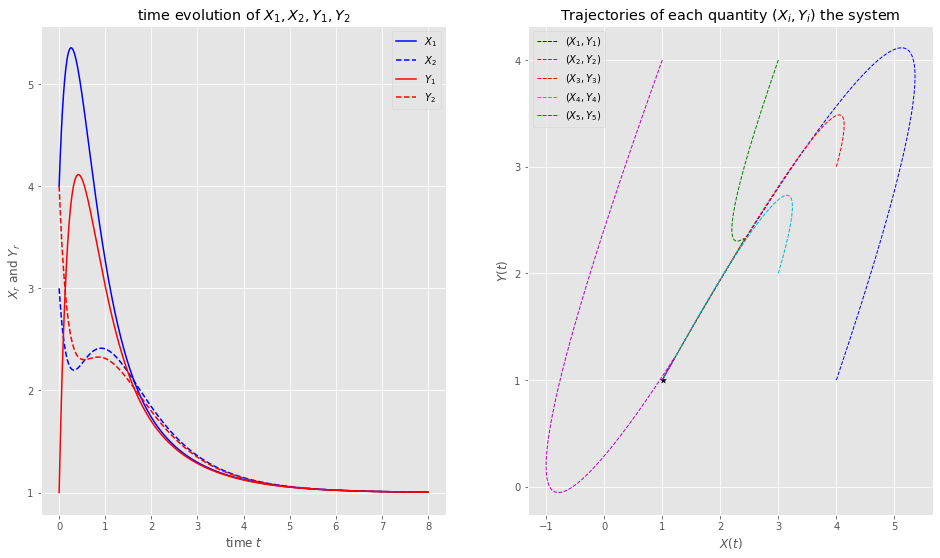

```python
## setup figure
fig, (a, b) = plt.subplots(1, 2)

# plot X_1, X_2, Y_1, Y_2 w.r.t. time
a.plot(time, y[:, 0], c='blue', label=r"$X_1$")
a.plot(time, y[:, 1], c='blue', ls="--", label=r"$X_2$")
a.plot(time, y[:, p + 0], c='red', label=r"$Y_1$")
a.plot(time, y[:, p + 1], c='red', ls="--", label=r"$Y_2$")

for i in range(p):
    b.plot(y[:, i], y[:, p + i], label=rf"$(X_{1+i}, Y_{1+i})$", lw=1, ls="--")

b.scatter(y[-1, 0], y[-1, p+0], c="black", marker="*")

# display parameters
a.set_title(r"time evolution of $X_1, X_2, Y_1, Y_2$")
b.set_title(r"Trajectories of each quantity $(X_i, Y_i)$ the system")

a.legend()
b.legend()

a.set_xlabel(r"time $t$")
a.set_ylabel(r"$X_r$ and $Y_r$");

b.set_xlabel(r"$X(t)$")
b.set_ylabel(r"$Y(t)$");
```

## Towards a more rigid structure of the code by refactoring previous chunks into a single function.

Since we will later want to test our code with different values of ($D_X, D_Y$) to witness Turing instabilities, let us build a function that draws a few trajectories given a set $(B, D_X, D_Y, p)$ (having in mind that we try to reproduce the six graphs from the slides). Therefore, the following function is nothing but a summary of what we said

```python
def build_trajectories(tau, B, D_X, D_Y, p, Z0=0):
    # retrieve coefficients of the B matrix
    b_xx = B[0, 0]
    b_xy = B[0, 1]
    b_yx = B[1, 0]
    b_yy = B[1, 1]

    # define each block of the M matrix (general case)
    Mxx = b_xx * I(p) - D_X * diffusion_matrix(p) # upper-left block
    Myy = b_yy * I(p) - D_Y * diffusion_matrix(p) # bottom-right block
    Mxy = b_xy * I(p) # upper-right block
    Myx = b_yx * I(p) # bottom-left block

    # the full M matrix
    M = np.block([[Mxx, Mxy], [Myx, Myy]])

    # vector of 1s
    v= np.ones(2*p)

    # function F
    F = lambda Z, t, M, v: M @ Z + v

    Tmax = tau

    if Z0 == 0:
        Z0 = np.random.randint(1, 20, 2*p) # choose a random starting point in [0, 2]^2p

    time = np.linspace(0, Tmax, N) # split [0, T] in N bits (discretize time)
    y = odeint(F, Z0, time, args=(M,v, )) # numerically solve the ODE system

    ## check stability
    eigs = np.linalg.eigvals(M)
    stab = 0
    for eig in eigs < 0:
        if eig == False:
            stab = 1

    # return the computed tailor-made solution + metadata
    return (y, p, D_X, D_Y, B, stab)
```

Notice this is nothing less than an adapted version of the last chunks of code. We can now fix $D_X := 0.5$ and test our function for different values of $D_Y$ in $[0.7, 1.2]$ to mimic the slides.

```python
p = 10 # amount of cells
T = 10 # simulation time
time = np.linspace(0, T, N)

D_X = 0.5 # diffusion of X
D_Ys = np.array([0.7 + 0.1*i for i in range(6)], dtype='float') # diffusion of Y

B = np.array([[5, -6],[6, -7]], dtype='float') # turing matrix B

## compute a solution FOR EACH D_Y
sols = []
for D_Y in D_Ys:
    sol = build_trajectories(T, B, D_X, D_Y, p)
    sols.append(sol)
```

Let us now plot each solution on a separate plot for the sake of readability (to this end, we will also plot only $X_1$, $X_2$, $Y_1$, $Y_2$ otherwise the plots are not readable).

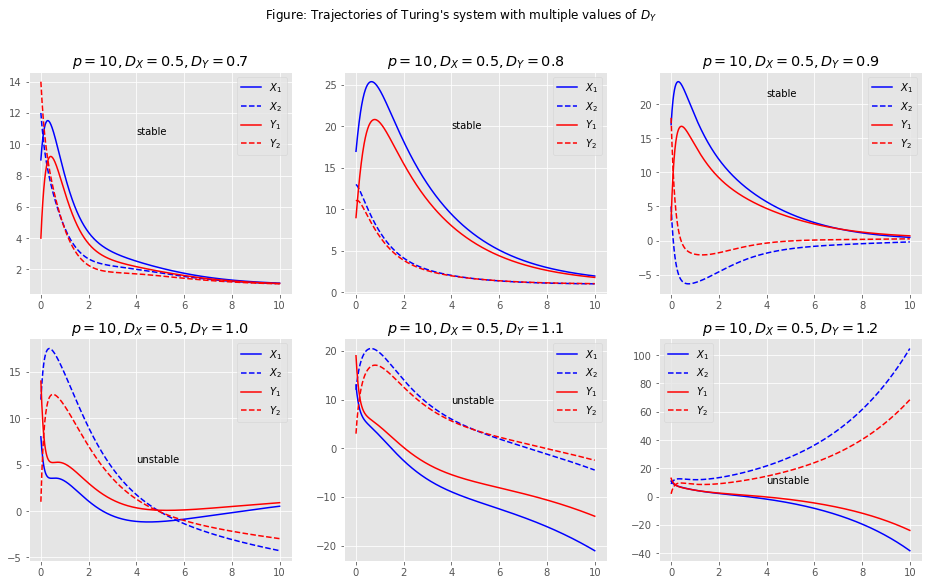

```python
fig, axs = plt.subplots(2, 3)

for i in range(2):
    for j in range(3):
        ax = axs[i, j] # fetch appropriate axis
        sol, p, dx, dy, b, stab = sols[2*i + j + i] # fetch appropriate sol

        stability = {0: "stable", 1: "unstable"}

        ## plot X_1, X_2, Y_1, Y_2
        ax.plot(time, sol[:, 0], 'blue', label=r"$X_1$")
        ax.plot(time, sol[:, 1], 'blue', ls="--", label=r"$X_2$")
        ax.plot(time, sol[:, p + 0], 'red', label=r"$Y_1$")
        ax.plot(time, sol[:, p + 1], 'red', ls="--", label=r"$Y_2$")

        ## display whether the system is stable or not
        ax_h, ax_w = ax.bbox.height/fig.dpi, ax.bbox.width/fig.dpi
        ax.text(4, sol[10, 0], stability[stab])

        ax.legend()
        ax.set_title(rf"$p = {p}, D_X = {np.round(dx, 3)}, D_Y = {np.round(dy, 3)}$")

plt.suptitle(r"Figure: Trajectories of Turing's system with multiple values of $D_Y$");
```

Here, we observe exactly what we expected... Fantastic!

## Finding diffusion coefficients inducing instabilities

As illustrated by the previous figure, there are some values of $(D_X, D_Y)$ for which, the system seems to behave completely differently. This is not magical, and we can show how this phenomenon happens. Without diffusion, the system has a stable equilibrium point at $Z^\star = [1, ..., 1]^T$ and one can quickly prove that adding diffusion back will not change the equilibrium's location but can, however, change its nature. Traditional methods for finding eigenelements of the Laplacian writing the system's matrix in a diagonalization basis for the operator $[\partial_t - \Delta]$ leads us to a condition of stability with respect to $D_X, D_Y$. First, introduce $B := \text{Jac}_F(Z^\star)$ and write $b_{xx},b_{xy}, b_{yx}, b_{yy}$ its coefficients as in the slides. Then, we can diagonalize the matrix $M$ such that

$$M := \begin{bmatrix}b_{xx} I_p - D_X A_p^d & b_{xy} I_p \\ b_{yx} I_p & b_{yy} I_p - D_y A_p^d \end{bmatrix} = Q \biggr[ \text{diag} \bigl( \bar M_2(\mu_1), \dots, \bar M_2(\mu_p) \bigr)\biggr] Q^{-1}$$

with

$$\mu_k := 2 \left( 1 - \cos\left( \frac{2k \pi}{p}\right)\right) \quad \text{ and } \quad \bar M_2(\mu_k) := \begin{bmatrix}b_{xx} - D_X \mu_k & b_{xy} \\ b_{yx} & b_{yy} - D_y \mu_k \end{bmatrix} \quad \text{ for } k \in [\![ 1, p ]\!]$$

Since it suffices for one block to have a positive eigenvalue to break unstability, i.e. $\text{Tr}\bar M_2({\mu_k}) < 0$ and $\det\bar M_2({\mu_k}) < 0$, or equivalently

$$Z^\star \text{ is unstable } \quad \iff \quad \exists k \in [\![ 1, p ]\!] \ : \quad \text{sp} \bigl( \bar M_2({\mu_k}) \bigr) \not\subset \mathbb R_{<0}$$

That being established, one can fairly easily show that $\text{Tr} \bar M_2({\mu_k}) = b_{xx} + b_{yy} - (D_X + D_Y)\mu_k < 0$ for all $k$ and that

$$\Pi(\mu) := \det \bar M_2({\mu}) = \det B - (b_{xx}D_Y + b_{yy} D_X) \mu + D_X D_Y \mu^2 \quad \text{ for } \mu \in \bigl\{ \mu_k \ \vert \ k = 1, ..., p-1\bigr\}$$

We recognize the expression of a polynomial in $\mu$. Since $D_X > 0$ and $D_Y > 0$, the parabola $\left( \mu, \Pi(\mu) \right)$ is oriented upwards. This means that $\Pi(\mu)$ can only take negative values if its determinant $\Delta_{\Pi}$ is positive, *i.e.*

$$(b_{xx}D_Y + b_{yy}D_X)^2 - 4 \bigl(\det B \bigr) D_X D_Y > 0 \quad \iff \quad (b_{xx}D_Y + b_{yy}D_X)^2 > 4 \bigl(\det B \bigr) D_X D_Y$$

We distinguish two cases: either $b_{xx} D_Y + b_{yy} D_X$ is negative or positive. The negative case is not interesting since it will provide two negative roots of $\Pi$. Since all $\mu_k$ are non-negative, we are only interested in positive values of $\mu$ and therefore, we could not reach a value of $\mu$ such that $\Pi(\mu) < 0$. We ignore this case and assume $b_{xx} D_Y + b_{yy} D_X > 0$, it follows

$$\Delta_{\Pi} > 0 \quad\iff\quad (b_{xx}D_Y + b_{yy}D_X) > 2 \sqrt{\det B} \sqrt{D_X D_Y} \quad\iff\quad b_{yy} \frac{D_X}{D_Y} - \bigl(2 \sqrt{\det B} \bigr) \sqrt{\frac{D_X}{D_Y}} + b_{xx} > 0$$

We thus introduce the parameter $\lambda := \sqrt{D_X}{D_Y}$ and the polynomial $P$ such that

$$P(\lambda) = b_{yy} \lambda^2 - \bigl(2 \sqrt{\det B} \bigr) \lambda + b_{xx}$$

The reader can show that $P$ always have a positive determinant and two roots: one positive, one negative. Thus, there always exists $\lambda > 0$ such that $P(\lambda) > 0$. We land on the following chain of equivalence:

$$\text{ System is unstable } \quad \iff \quad \exists \mu_-, \ \exists\mu_+ \in \mathbb R_{>0} \ \ \bigl\vert \ \ \Pi(\mu) < 0 \ \text{ if } \mu \in (\mu_-, \mu_+) \quad \iff \quad P(\lambda) > 0$$

> **Remark:** Notice how the role of $D_X$ is important for the system to be unstable! The parabola is fixed at the origin at the point $\bigl(0, \det(B) \bigr)$. Meaning that the only way for the parabola to reach a negative minimum is by playing on the $\mu$ and $\mu^2$ coefficients which, roughly, control the offset from the origin and the overture of the parabola respectively. To ensure unstability of the system, it is better to pick a small value of $D_X$ that will make the parabola very steep near $\bigl(0, \det (B) \bigr)$ and choose a large $D_Y$ to make a parabola that crosses the $x$-axis near the origin and that becomes positive the farthest possible. This way, all eigenmodes $\mu_k \in [0, 4]$ are more likely lie within the interval on which $\Pi$ is negative and thus, inducing more unstable blocks (even though one is enough to break the system)!

Notice that the condition $b_{xx} D_Y + b_{yy} D_X > 0$ can now be rewritten as $\lambda < \sqrt{- b_{xx} / b_{yy}}$ which is always satified if $P(\lambda) > 0$. Further, in Turing's system, $P(\lambda) = -7 \lambda^2 - 2 \lambda + 5$, which has a positive determinant $\Delta = (-2)^2 - 4(-7)(5) = 144$. $P$ is thus an upside-down parabola with two roots $\{\lambda_{-}, \lambda_{+}\} = \{- (2 \pm 12) / 14\} = \{-1, 5/7\}$. Let us pick any $\lambda \in (0, 5/7)$, choose $k \in (1, p)$ ($k$ = the block we force a positive eigenvalue in), and compute the appropriate set $D_X, D_Y$ to induce instabilities.

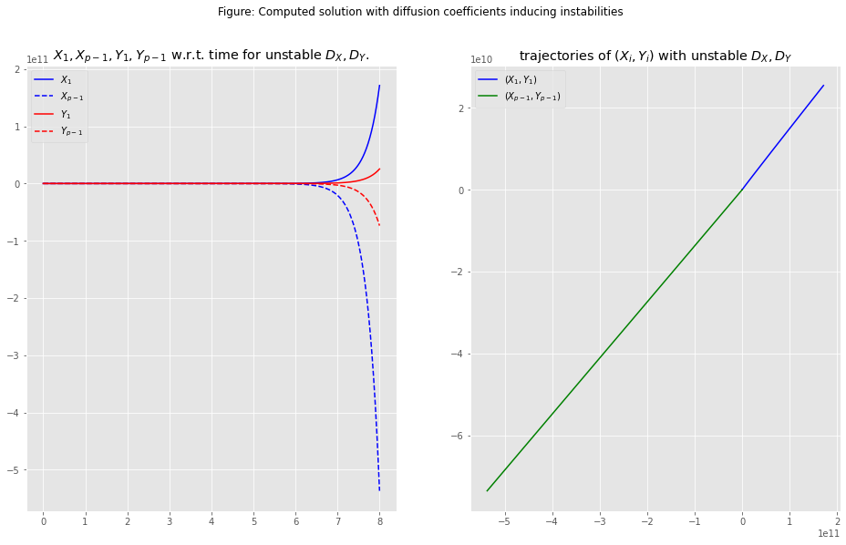

```python
## pick k in {1, ..., p} as desired
k = 4

## compute the value of mu_k
mu_k = 2 * (1 - np.cos(2*k*pi / p)) # value of mu in the k-th bloc of \bar{M}

## define lambda and lambda^2 as in the slides
lam = 2/14
lam2 = lam * lam

## need those guys
b_xx = B[0, 0]
b_xy = B[0, 1]
b_yx = B[1, 0]
b_yy = B[1, 1]

## compute values of D_X and D_Y inducing instabilities
newD_X = (b_xx + b_yy * lam2) / (2 * mu_k)
newD_Y = D_X / lam2

## compute solution with new values of D_X and D_Y
T = 8
time = np.linspace(0, T, N)

## build unstable trajectory
sol, p, dx, dy, b, stab = build_trajectories(T, B, newD_X, newD_Y, p)

fig, (a, b) = plt.subplots(1, 2)

## plot new solution
a.plot(time, sol[:, 0], 'blue', label=r"$X_1$")
a.plot(time, sol[:, p-1], 'blue', ls="--", label=r"$X_{p-1}$")
a.plot(time, sol[:, p + 0], 'red', label=r"$Y_1$")
a.plot(time, sol[:, p + p-1], 'red', ls="--", label=r"$Y_{p-1}$");
a.legend()

## plot unstable trajectories
b.plot(sol[:, 0], sol[:, p+0], label=r"$(X_1, Y_1)$")
b.plot(sol[:, p-1], sol[:, p+p-1], label=(r"$(X_{p-1}, Y_{p-1})$"))
b.legend()

a.set_title(r"$X_1, X_{p-1}, Y_1, Y_{p-1}$ w.r.t. time for unstable $D_X, D_Y$.")
b.set_title(r"trajectories of $(X_i, Y_i)$ with unstable $D_X, D_Y$")


plt.suptitle("Figure: Computed solution with diffusion coefficients inducing instabilities");
```

## Instabilities in the general case and some more refactoring

In this next part, we answer the question: "what happens when $f$ and $g$ change? In fact, the previous analysis can be adapted to the general case provided that the reaction functions are differentiable. More precisely, instead of working with $5, -6, 6, 7$, we work with

$$B = \begin{bmatrix} b_{xx} & b_{xy} \\ b_{yx} & b_{yy} \end{bmatrix} := \begin{bmatrix} \partial_{x} f(X^\star, Y^\star) & \partial_{y} f(X^\star, Y^\star) \\ \partial_{x} g(X^\star, Y^\star) &\partial_{y} g(X^\star, Y^\star)\end{bmatrix}$$

We follow the same recipe to produce instabilities. In a quest of generality, we define a new function that, given the jacobian matrix $B$ computed at an equilibrium and a number of cell $p$, returns values of $D_X$, $D_Y$ based on our method.

```python
def generate_unstable_DX_DY(B, p):
    ## fetch coefficients of B
    bxx = B[0, 0]
    bxy = B[0, 1]
    byx = B[1, 0]
    byy = B[1, 1]

    ## trace and determinant
    trB = bxx + byy
    detB = bxx * byy - byx * bxy
    sqrtdetB = np.sqrt(detB)

    ## roots of byy * L^2 - 2 sqrt(det(B)) * L + bxx = 0
    lam_p = (sqrtdetB - np.sqrt(-bxy * byx)) / byy
    lam_m = (sqrtdetB + np.sqrt(-bxy * byx)) / byy

    ## choose 0 < lambda < lam_m
    lam = lam_p/2

    ## Take a given 1 < k < p and compute mu_k
    k = p//4
    mu_k = 2 * (1 - np.cos(2*k*np.pi / p))

    ## compute D_X
    D_X = ( bxx + byy * (lam**2) ) / ( 2 * mu_k )

    ## compute D_Y
    D_Y = D_X / (lam * lam)

    ## return the new diffusion coeffs inducing instabilities
    return (D_X, D_Y)
```

## Testing the code

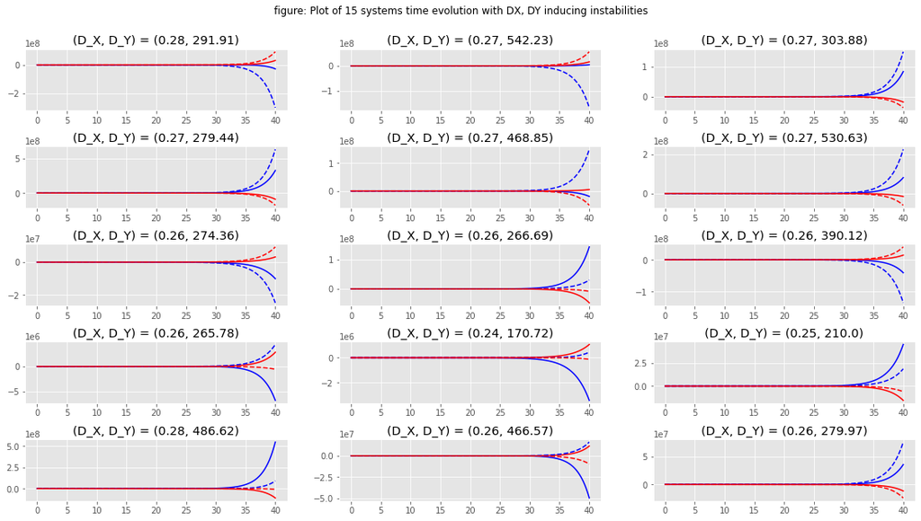

```python
## choose a value of p
p = 30

## setup the array
B = np.zeros((2, 2))

## define the amount of solutions we want to generate (multiple of 3 for display reasons)
N_sol = 15

## time on which we integrate the system
T = 40

## time mesh
time = np.linspace(0, T, N)

## compute dimension of plot subarrays
width = 3
height = N_sol // 3

## prepare figure
fig, axs = plt.subplots(height, width)
fig.tight_layout(pad=2.5)
fig.subplots_adjust(top=0.9)

## for each plot
for i in range(width):
    for j in range(height):
        ## choose appropriate axis
        ax = axs[j, i]

        ## generate a random matrix B
        # bxx: will be 1 all the time
        B[0, 0] = 1

        # bxy: can be one without loss of generality
        B[0, 1] = 1

        # byy: must be negative with bxx + byy < 0
        B[1, 1] = np.random.randint(low=-100, high=B[0, 0] - 1)

        # byx: must be negative, greater than bxx * byy
        # such that bxx*byy - bxy*byx > 0 <-> -bxy > -byy
        B[1, 0] = np.random.randint(low= B[1, 1] - 100, high=B[1, 1] - 1)

        ## generate values of DX, DY
        DX, DY = generate_unstable_DX_DY(B, p)

        ## compute the numerical solution on [0, T]
        sol, p, dx, dy, b, stab = build_trajectories(T, B, DX, DY, p)

        ## fetch some quantities
        X1 = sol[:, 0]
        Y1 = sol[:, p+0]

        X2 = sol[:, 1]
        Y2 = sol[:, p+1]

        ax.plot(time, X1, c="blue")
        ax.plot(time, Y1, c="red")

        ax.plot(time, X2, c="blue", ls="--")
        ax.plot(time, Y2, c="red", ls="--")

        ax.set_title(f"(D_X, D_Y) = {np.round(DX, 2), np.round(DY, 2)}")


plt.suptitle(f"figure: Plot of {N_sol} systems time evolution with DX, DY inducing instabilities")
plt.show();
```

## Phase space of diffusion coefficients given a matrix $B$

To conclude this section, we propose a snippet of code that allows one to visualize which values of $D_X$ and $D_Y$ one should pick to guarantee the existence of at least one unstable eigenspacee given a system matrix $B$ (more precisely, its coefficients $b_{xx}$, $b_{xy}$, $b_{yx}$, $b_{yy}$). Enjoy!

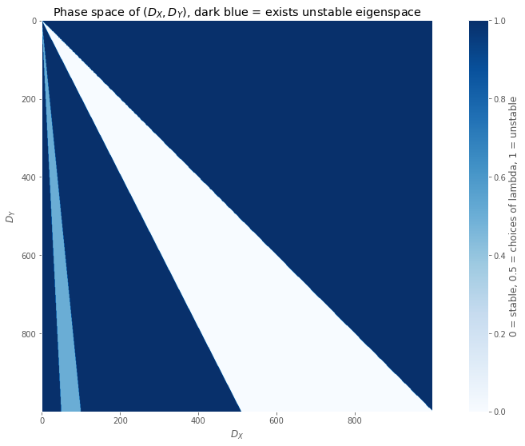

```python
## amount of cells
p = 20

## give a matrix B
bxx = 5
bxy = -6
byy = -7
byx = 6

## check is the system is stable without diffusion
if bxx + byy > 0:
    print("trace positive, reaction system unstable")

if bxx*byy - byx*bxy < 0:
    print("determinant negative, reaction system unstable")

## set of values for DX
DXs = np.linspace(0, 1000, 1000)

## set of values for DY
DYs = np.linspace(0, 1000, 1000)

## condition on DX, DY to have potential unstabilities
test = lambda DX, DY: (bxx*DY + byy*DX)**2 - 4*DX*DY > 0

## heatmap of (DXs, DYs)
heatmap = np.zeros((1000, 1000))

fig, ax = plt.subplots()

## fill heatmap
for i, DX in enumerate(DXs):
    for j, DY in enumerate(DYs):
        heatmap[j, i] = 1 if test(DX, DY) else 0
        if DX < 0.1 * DY + 0.1 and DX > 0.05 * DY - 0.1:
            heatmap[j, i] = 0.5

## build heatmap
im = ax.imshow(heatmap, cmap="Blues")

## Plotting a pretty heatmap
plt.title("Phase space of $(D_X, D_Y)$, dark blue = exists unstable eigenspace")
ax.grid(False)

cbar = plt.colorbar(im)
cbar.set_label("0 = stable, 0.5 = choices of lambda, 1 = unstable")

plt.xlabel(r"$D_X$")
plt.ylabel(r"$D_Y$")

plt.show()
```

## Interpretation of the phase space figure

> **Remark:** notice that the light blue cone is included in the dark blue cone. Meaning that any value we pick in the light blue cone generates a pair $(D_X, D_Y)$ susceptible to make the system unstable.

A possible interpretation would be that the system is stable for diffusion coefficients that are roughly of the same magnitude which corroborates illustrations coming from real life applications!

## A non-linear example with Bard-Lauder's model

### Without diffusion

In order to illustrate the results of the previous section, we take the example of the Bard-Lauder model, which introduces the two positive parameters $\beta$, $\sigma$ (I have chosen to replace $S$ by $\sigma$ for practical reasons), as well as the functions

$$f_{\beta, \sigma}(X, Y) = \frac{\sigma}{16}\bigl( 16 - XY \bigr), \quad \quad g_{\beta, \sigma}(X, Y) = \frac{\sigma}{16} \bigl( XY - Y - \beta \bigr)$$

The usual routine invites us into finding critical points of the system $(X^\star, Y^\star)$ such that $f_{\beta, \sigma}(X^\star, Y^\star) = g_{\beta, \sigma}(X^\star, Y^\star) = 0$. Notice that the case $\beta = 16$ provides no valid solution ($Y^\star = 0 \text{ and } X^\star Y^\star = 16$), this is why we assume $\beta \ne 16$ for the rest of the section.

$$ \begin{cases} f_{\beta, \sigma} \bigl( X^\star, Y^\star \bigr) = 0 \\ g_{\beta, \sigma} \bigl(X^\star, Y^\star \bigr) = 0 \end{cases} \iff \begin{cases} \frac{\sigma}{16} \bigl( 16 - X^\star Y^\star \bigr) = 0 \\ \frac{\sigma}{16} \bigl( X^\star Y^\star - Y^\star - \beta \bigr) = 0 \end{cases} \iff \begin{cases} X^\star Y^\star = 16 \\ Y^\star = X^\star Y^\star - \beta \end{cases} \iff \begin{cases} X^\star = \frac{16}{16 - \beta} \\ Y^\star = 16 - \beta \end{cases} $$

We can then compute the matrix $B(\beta, \sigma)$ (or interchangeably $B$ for short) which, we recall, is none other than the Jacobi matrix evaluated at the critical point, *i.e.* $B(\beta, \sigma) = \text{Jac}_{(f_{\beta, \sigma}, g_{\beta, \sigma})} (X^\star, Y^\star)$ , hence

$$B(\beta, \sigma) = \frac{\sigma}{16}\begin{bmatrix} \beta - 16 & - \frac{16}{16 - \beta} \\ 16 - \beta & \frac{16}{16 - \beta} - 1\end{bmatrix}$$

We continue our journey by restraining our parameter space to the set $\Gamma = \bigl\{ (\beta, \sigma) \ \ \bigl\vert \ \ \text{Tr}(B(\beta, \sigma)) < 0 \text{ and } \det(B(\beta, \sigma)) > 0\bigr\}$. To obtain an explicit definition of $\Gamma$, we proceed to a closer examination for both conditions, starting with the determinant (recall $\sigma / 16 > 0$).

$$ \begin{equation} \label{trcond} \det(B) > 0 \quad\iff\quad (\beta-16) \left( \frac{16}{16 - \beta} - 1 \right) - (16-\beta)\frac{16}{16 - \beta} > 0 \quad \iff\quad 16 - \beta > 0 \quad \iff\quad \beta < 16 \end{equation} $$

moving on to the trace...

$$ \begin{align*} \text{Tr}(B) < 0 \quad &\iff \quad (\beta - 16) + \frac{16}{16 - \beta} - 1 < 0 \\ \scriptsize{(\text{same denominator})}& \iff\quad \frac{-(16 - \beta)^2 + 16 - (16-\beta)}{16 - \beta} < 0 \\[0.8em] \scriptsize{(16 - \beta > 0 \text{ by (1)})} &\iff\quad \beta - (16 - \beta)^2 < 0 \\[0.8em] \scriptsize{(\text{let }\alpha = \beta - 16)} &\iff \quad \alpha^2 - \alpha - 16 > 0 \end{align*} $$

Solve for alpha and replace $\beta = \alpha + 16$, it all boils down to $\beta \in \left(-\infty, \frac{1}{2}\bigl ( 33 - \sqrt{65} \bigr) \right)$. Notice that the case $\beta \in \left( 16, \frac{1}{2} \bigl( 33 + \sqrt{65} \bigr)\right)$ is eliminated by condition (\ref{trcond}). We finally get the condition for stability

$$ \begin{equation} \text{Tr}(B) < 0 \text{ and } \det(B) > 0 \quad \iff \quad \beta < \frac{33}{2} - \frac{\sqrt{65}}{2} \end{equation} $$

Let us now implement the system without diffusion on $p=1$ cell to illustrate our recent findings. We will take inspiration from Bard and Lauder's paper for the values of $\sigma$ and $\beta$.

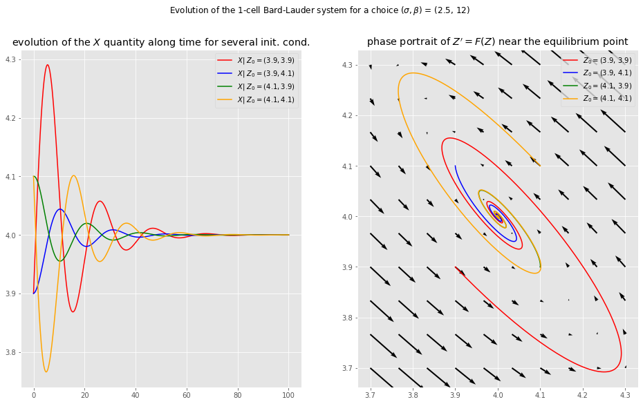

```python
## define sigma and beta
s = 2.5
b = 12

## matrix coefficients for Bard-Lauder model
bxx = (s / 16) * (b - 16)
bxy = - (s / 16) * 16 / (16 - b)
byx = (s / 16) * (16 - b)
byy = (s / 16) * (16 / (16 - b) - 1)

## whole Bard-Lauder B matrix
B = np.array([[bxx, bxy], [byx, byy]])

## time domain [0, T]
T = 100
time = np.linspace(0, T, 1000)

## Z' = F(Z)
F = lambda Z, t, s, b: [(s / 16) * (16 - Z[0]*Z[1]), (s / 16) * (Z[0]*Z[1] - Z[1] - b)]

## set of initial conditions
Z0s = [[4 + i, 4 + j] for i in [-0.1, 0.1] for j in [-0.1, 0.1]]

## numerical solution for each initial condition
ys = []

## set of colors for each starting point
colors = ['red', 'blue', 'green', 'orange']

## prepare figure
fig, ax = plt.subplots(1, 2)

## compute numerical solution and plot (t, X(t)) then (X(t), Y(t)) for each init. cond.
for c, Z0 in enumerate(Z0s):
    y_z0 = odeint(F, Z0, time, args=(s, b, ))
    ax[0].plot(time, y_z0[:, 0], colors[c], label=rf"$X \vert \ Z_0 = ({Z0[0]}, {Z0[1]})$")
    ax[1].plot(y_z0[:, 0], y_z0[:, 1], colors[c], label=fr"$Z_0 = $({Z0[0]}, {Z0[1]})")


## -- begin vector field of the differential equation
X1 = np.linspace(3.7, 4.3, 10)
X2 = np.linspace(3.7, 4.3, 10)

Y1, Y2 = np.meshgrid(X1, X2)
U, V = np.zeros(Y1.shape), np.zeros(Y2.shape)

NI, NJ = Y1.shape

for i in range(NI):
    for j in range(NJ):
        x = Y1[i, j]
        y = Y2[i, j]
        yprime = F([x, y], 0, s, b)
        U[i,j] = yprime[0]
        V[i,j] = yprime[1]

ax[1].quiver(Y1, Y2, U, V, color='black', width=0.005)
## -- end of vector field plotting


## paste legend on figures
ax[0].legend();
ax[1].legend();

## name each graph
ax[0].set_title("evolution of the $X$ quantity along time for several init. cond.")
ax[1].set_title(fr"phase portrait of $Z' = F(Z)$ near the equilibrium point")

## give a global title
plt.suptitle(rf"Evolution of the 1-cell Bard-Lauder system for a choice $(\sigma, \beta)$ = ({s}, {b})");
```

We notice that the system converges well in the closed ball $\mathcal B \bigl((X^\star, Y^\star), 0.1 \bigr)$. However, one must be careful because this property is only local ! Indeed, with a more advanced software (Grapher on MacOS) one can draw the phase portrait as well as some trajectories for starting points getting further from the critical point $(X^\star, Y^\star)$ (with the same parameters).

[output not shown]

### Adding diffusion back in the system

When adding diffusion back to the system we can use our previously defined functions to compute values of $(D_X, D_Y)$. Let us fix $p = 20$.

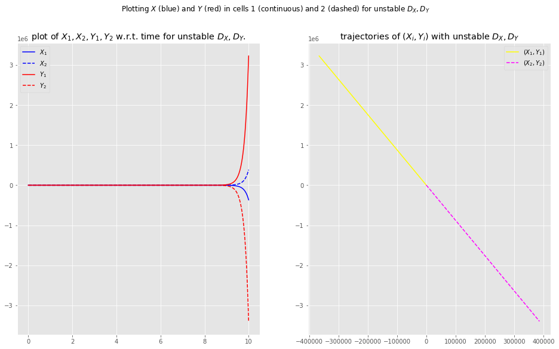

```python
## fix a number of cells
p = 20

## Bard-Lauder parameters
s = 2
b = 12

## compute associated diffusion coefficients
DX, DY = generate_unstable_DX_DY(B, p)

## time interval [0, T]
T = 10
time = np.linspace(0, T, 1000)

## pick the same starting point for each X_r and Y_r
x0 = 16/(16-b) + 0.1
y0 = 16 - b + 0.3

## provide a starting point close to (16/(16 - beta), 16 - beta)
Z0 = [x0] * p + [y0] * p


## run simulations with these coefficients
sol, p, dx, dy, b, stab = build_trajectories(T, B, DX, DY, p, Z0=Z0)

fig, (a, b) = plt.subplots(1, 2)

a.plot(time, sol[:, 0], c="blue", label=r"$X_1$")
a.plot(time, sol[:, 1], c="blue", ls ="--", label=r"$X_2$")
a.plot(time, sol[:, p + 0], c="red", label=r"$Y_1$")
a.plot(time, sol[:, p + 1], c="red", ls ="--", label=r"$Y_2$")

b.plot(sol[:, 0], sol[:, p+0], c="yellow", label=r"$(X_1, Y_1)$")
b.plot(sol[:, 1], sol[:, p+1], c="magenta", ls ="--", label=r"$(X_2, Y_2)$")

a.set_title(r"plot of $X_1, X_2, Y_1, Y_2$ w.r.t. time for unstable $D_X, D_Y$.")
b.set_title(r"trajectories of $(X_i, Y_i)$ with unstable $D_X, D_Y$")


plt.suptitle(r"Plotting $X$ (blue) and $Y$ (red) in cells 1 (continuous) and 2 (dashed) for unstable $D_X, D_Y$")
a.legend();
b.legend();
```

Which is clearly unstable as expected and concludes this report at the same time.

#### Thank you for reading this report -- Théo André